# Contacts Check Script

Ali Colmenares and Kendra Wyant

2020-10-16

### Notes

This script checks data from RISK participants’ contacts reports by computing descriptives and checking for missingness and potential errors

### Setup

Paths

```r
path_data <- "./analysis/shared/data"
```

Packages

```r
library(janitor)
library(lubridate)
library(kableExtra)
library(tidyverse)
library(psych)
```

### Import Data and Glimpse

Contacts data

```r
contacts <- read_rds(file.path(path_data, "ds_contacts_report.rds")) %>%
  glimpse()
```

```
## Rows: 7,077
## Columns: 13
## $ subid          <dbl> 1, 1, 1, 1, 1, 1, 1, 1, 1, 2, 2, 2, 2, 2, 2, 2, 2…
## $ utc            <dbl> 1487871000, 1487871000, 1487871000, 1487871000, 1…
## $ home_phone     <dbl> NA, 6082227282, NA, NA, NA, NA, NA, NA, NA, NA, N…
## $ cell_phone     <dbl> 6083588174, NA, 6085149557, 6084385017, 608213191…
## $ other_phone1   <dbl> NA, NA, NA, NA, NA, NA, NA, NA, NA, NA, NA, NA, N…
## $ other_phone2   <dbl> NA, NA, NA, NA, NA, NA, NA, NA, NA, NA, NA, NA, N…
## $ type           <chr> "SELF", "PARENT", "OTHER", "FRIEND", "CO-WORKER/B…
## $ drank_past     <chr> NA, "NEVER/ALMOST NEVER", "NEVER/ALMOST NEVER", "…
## $ drinker_status <chr> NA, "DRINKER", "NONDRINKER", "NONDRINKER", "DONT …
## $ drink_future   <chr> NA, "YES", "NO", "NO", "NO", "YES", "YES", "NO", …
## $ recovery       <chr> NA, "NO", "YES", "DONT KNOW", "YES", "NO", "NO", …
## $ support        <chr> NA, "SUPPORTIVE", "NEUTRAL", "SUPPORTIVE", "SUPPO…
## $ emotion        <chr> NA, "MIXED", "MIXED", "PLEASANT", "PLEASANT", "PL…
```

narrow phone types to type and phone column

```r
# add identifier for contacts since some have more than one number
contacts <- contacts %>%
  mutate(cont_sub = 1000 + (1:nrow(contacts)))

# gather to separate phone numbers into their own rows
contacts <- contacts %>%
  gather(phone_type, number, home_phone:other_phone2) %>%
  filter(!is.na(number)) %>%
  select(subid, cont_sub, phone_type, number,
         contact_type = type,
         everything(),
         -utc) %>%
  glimpse()
```

```
## Rows: 7,201
## Columns: 11
## $ subid          <dbl> 1, 6, 6, 6, 6, 6, 6, 15, 15, 15, 15, 16, 18, 18, …
## $ cont_sub       <dbl> 1002, 1110, 1111, 1115, 1116, 1117, 1119, 1296, 1…
## $ phone_type     <chr> "home_phone", "home_phone", "home_phone", "home_p…
## $ number         <dbl> 6082227282, 4142182748, 4147717900, 6082323171, 6…
## $ contact_type   <chr> "PARENT", "IRRELEVANT/SPAM", "IRRELEVANT/SPAM", "…
## $ drank_past     <chr> "NEVER/ALMOST NEVER", NA, NA, NA, NA, NA, NA, "OC…
## $ drinker_status <chr> "DRINKER", NA, NA, NA, NA, NA, NA, "DRINKER", "NO…
## $ drink_future   <chr> "YES", NA, NA, NA, NA, NA, NA, "YES", "NO", "NO",…
## $ recovery       <chr> "NO", NA, NA, NA, NA, NA, NA, "NO", "DONT KNOW", …
## $ support        <chr> "SUPPORTIVE", NA, NA, NA, NA, NA, NA, "SUPPORTIVE…
## $ emotion        <chr> "MIXED", NA, NA, NA, NA, NA, NA, "PLEASANT", "PLE…
```

### Missing data

View _contacts with missing data

```r
if(any(is.na(contacts))){
  missing <- contacts %>%
    summarise(across(everything(), ~sum(is.na(.)))) %>%
    gather(key = "var", value = "num_NA" ) %>%
    filter(num_NA > 0)
  missing %>%
    kable(caption = "Variables with missing values", table.attr = "style='width:40%;'") %>%
    kable_styling(position = "left", bootstrap_options = "condensed")
}else {
  paste("No missing values")
}
```

Variables with missing values

| var | num_NA |
| --- | --- |
| contact_type | 3 |
| drank_past | 2376 |
| drinker_status | 2376 |
| drink_future | 2379 |
| recovery | 2378 |
| support | 2376 |
| emotion | 2375 |

There are now 14263 missing values (NA) from 7 unique variables in the entire dataset

Missing contact_type

```r
contacts %>%
  filter(is.na(contact_type)) %>%
  kable() %>%
  kable_styling(bootstrap_options = "condensed")
```

| subid | cont_sub | phone_type | number | contact_type | drank_past | drinker_status | drink_future | recovery | support | emotion |
| --- | --- | --- | --- | --- | --- | --- | --- | --- | --- | --- |
| 16 | 1353 | cell_phone | 6085163702 | NA | NEVER/ALMOST NEVER | NONDRINKER | NO | NO | DONT KNOW | PLEASANT |
| 18 | 1448 | cell_phone | 6082359642 | NA | ALMOST ALWAYS/ALWAYS | DRINKER | YES | NO | DONT KNOW | PLEASANT |
| 56 | 2893 | cell_phone | 6083457045 | NA | OCCASIONALLY | DRINKER | NO | NO | SUPPORTIVE | PLEASANT |

It appears as though the NA should be either reclassified as “other” or removed Because the rest of the variables have valid data, the contacts will be classified as “other”

Reclassify type from NA to other

```r
contacts <- contacts %>%
  mutate(
    contact_type = case_when(
    subid == 16 & is.na(contact_type) ~ "OTHER",
    subid == 18 & is.na(contact_type) ~ "OTHER",
    subid == 56 & is.na(contact_type) ~ "OTHER",
    TRUE ~ contact_type))
```

There are 2189 irrelevant/spam contacts and about 2376 contacts with missing context variables.

Missing context variables

```r
contacts %>%
  filter(contact_type != "IRRELEVANT/SPAM" & is.na(drank_past)) %>%
  group_by(contact_type) %>%
  summarise(n = n()) %>%
  kable(table.attr = "style='width:60%;'") %>%
  kable_styling(position = "left")
```

| contact_type | n |
| --- | --- |
| CO-WORKER/BUSINESS CONTACT | 3 |
| COUNSELOR | 1 |
| FAMILY-OTHER | 3 |
| FRIEND | 6 |
| OTHER | 5 |
| SELF | 168 |
| SOCIAL WORKER/CASE MANAGER | 1 |

168 of the 187 non-spam contacts with missing context variables are identified as self.

Participants with self contact

```r
contacts %>%
  filter(contact_type == "SELF") %>%
  group_by(subid) %>%
  summarise(n = n())
```

```
## # A tibble: 154 x 2
##    subid     n
##    <dbl> <int>
##  1     1     1
##  2     2     1
##  3     3     1
##  4     5     1
##  5     6     1
##  6     7     1
##  7     9     1
##  8    10     1
##  9    11     1
## 10    15     1
## # … with 144 more rows
```

```r
contacts %>%
  filter(contact_type == "SELF") %>%
  group_by(subid) %>%
  summarise(n = n()) %>%
  filter(n > 1)
```

```
## # A tibble: 12 x 2
##    subid     n
##    <dbl> <int>
##  1    30     2
##  2    42     2
##  3    77     2
##  4    85     2
##  5   100     2
##  6   135     2
##  7   143     2
##  8   150     2
##  9   187     3
## 10   203     2
## 11   236     2
## 12   252     3
```

Temporarily remove self contacts

```r
contacts <- contacts %>%
  filter(contact_type != "SELF")
```

Remaining missing values

```r
contacts %>%
  filter(contact_type != "IRRELEVANT/SPAM") %>%
  summarise(across(everything(), ~sum(is.na(.)))) %>%
  gather(key = "var", value = "num_NA" ) %>%
  filter(num_NA > 0) %>%
  kable(table.attr = "style='width:60%;'") %>%
  kable_styling(position = "left")
```

| var | num_NA |
| --- | --- |
| drank_past | 19 |
| drinker_status | 19 |
| drink_future | 22 |
| recovery | 21 |
| support | 19 |
| emotion | 18 |

Missing context variables

```r
contacts %>%
  filter(contact_type != "IRRELEVANT/SPAM") %>%
  filter(is.na(drink_future)) %>%
  kable() %>%
  kable_styling()
```

| subid | cont_sub | phone_type | number | contact_type | drank_past | drinker_status | drink_future | recovery | support | emotion |
| --- | --- | --- | --- | --- | --- | --- | --- | --- | --- | --- |
| 18 | 1490 | home_phone | 6088498385 | CO-WORKER/BUSINESS CONTACT | NA | NA | NA | NA | NA | NA |
| 26 | 1702 | home_phone | 7736993784 | FRIEND | NA | NA | NA | NA | NA | NA |
| 54 | 2810 | home_phone | 6084419990 | OTHER | NA | NA | NA | NA | NA | MIXED |
| 64 | 3078 | home_phone | 6082572542 | SOCIAL WORKER/CASE MANAGER | NA | NA | NA | NA | NA | NA |
| 77 | 3238 | home_phone | 6082407504 | CO-WORKER/BUSINESS CONTACT | NA | NA | NA | NA | NA | NA |
| 6 | 1093 | cell_phone | 2093664651 | CO-WORKER/BUSINESS CONTACT | NEVER/ALMOST NEVER | NA | NA | NO | DONT KNOW | PLEASANT |
| 26 | 1701 | cell_phone | 6082283374 | FAMILY-OTHER | NA | NA | NA | NA | NA | NA |
| 26 | 1702 | cell_phone | 3128414983 | FRIEND | NA | NA | NA | NA | NA | NA |
| 26 | 1703 | cell_phone | 8052940369 | FRIEND | NA | NA | NA | NA | NA | NA |
| 29 | 1839 | cell_phone | 6086206239 | OTHER | NA | NA | NA | NA | NA | NA |
| 33 | 2045 | cell_phone | 6082407426 | CO-WORKER/BUSINESS CONTACT | NA | NA | NA | NA | NA | NA |
| 66 | 3138 | cell_phone | 6087701430 | CO-WORKER/BUSINESS CONTACT | NEVER/ALMOST NEVER | DONT KNOW | NA | DONT KNOW | NEUTRAL | NEUTRAL |
| 66 | 3140 | cell_phone | 6082138473 | FRIEND | NEVER/ALMOST NEVER | DONT KNOW | NA | NA | NEUTRAL | NEUTRAL |
| 66 | 3145 | cell_phone | 6304867412 | FAMILY-OTHER | NA | NA | NA | NA | DONT KNOW | NA |
| 66 | 3156 | cell_phone | 6084512714 | FAMILY-OTHER | NA | NA | NA | NA | NA | NA |
| 143 | 4832 | cell_phone | 6088077658 | FRIEND | NA | NA | NA | NA | NA | NA |
| 201 | 6403 | cell_phone | 6082142233 | CO-WORKER/BUSINESS CONTACT | NEVER/ALMOST NEVER | DRINKER | NA | DONT KNOW | DONT KNOW | PLEASANT |
| 6 | 1090 | other_phone1 | 6082636100 | OTHER | NA | NA | NA | NA | NA | NA |
| 6 | 1092 | other_phone1 | 6088374814 | COUNSELOR | NA | NA | NA | NA | NA | NA |
| 26 | 1702 | other_phone1 | 4242394294 | FRIEND | NA | NA | NA | NA | NA | NA |
| 27 | 1746 | other_phone1 | 8774155164 | OTHER | NA | NA | NA | NA | NA | NA |
| 255 | 7648 | other_phone1 | 622622 | OTHER | NA | NA | NA | NA | NA | NA |

Subids 26, 6, 66 make up 12 of the 22 contacts with missing context variables

### Descriptives

#### Contacts per participant

Average number of contacts for each participant

```r
n_contacts <- contacts %>%
  group_by(subid) %>%
  summarise(n_contacts = length(unique(cont_sub)))

describe(n_contacts$n_contacts) %>%
  round(2) %>%
  select(n:se) %>%
  kable() %>%
  kable_styling() %>%
  add_header_above(c("Total number of contacts per participant (with spam)" = 13))
```

| Total number of contacts per participant (with spam) | Total number of contacts per participant (with spam) n | Total number of contacts per participant (with spam) mean | Total number of contacts per participant (with spam) sd | Total number of contacts per participant (with spam) median | Total number of contacts per participant (with spam) trimmed | Total number of contacts per participant (with spam) mad | Total number of contacts per participant (with spam) min | Total number of contacts per participant (with spam) max | Total number of contacts per participant (with spam) range | Total number of contacts per participant (with spam) skew | Total number of contacts per participant (with spam) kurtosis | Total number of contacts per participant (with spam) se |
| --- | --- | --- | --- | --- | --- | --- | --- | --- | --- | --- | --- | --- |
| X1 | 154 | 44.94 | 28.78 | 39.5 | 41.39 | 24.46 | 3 | 184 | 181 | 1.56 | 3.68 | 2.32 |

The overall average number of contacts reported by participants was 44.94.

facet by spam

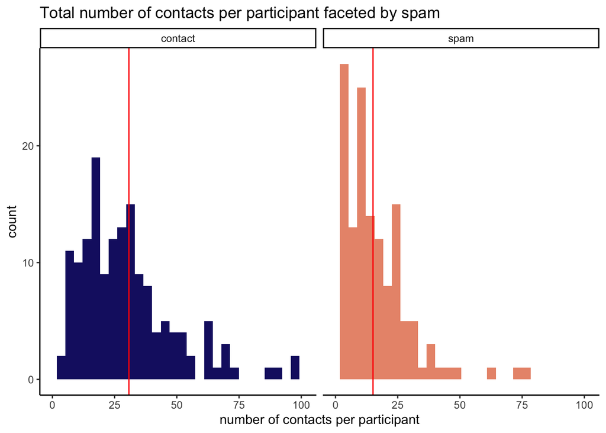

```r
contacts <- contacts %>%
  mutate(spam = case_when(contact_type == "IRRELEVANT/SPAM" ~ "spam",
                          contact_type != "IRRELEVANT/SPAM" ~ "contact"))

contacts %>%
  group_by(subid, spam) %>%
  summarise(n_contacts = length(unique(cont_sub))) %>%
  mutate(n_contacts = case_when(n_contacts > 100 ~ as.double(100),
                   TRUE ~ as.double(n_contacts))) %>%
  ggplot(aes(x = n_contacts, fill = spam)) +
  geom_histogram() +
  facet_wrap(~spam) +
  theme_classic() +
  theme(legend.position = "none") +
  xlim(0,101) +
  scale_fill_manual(values = c("midnightblue", "darksalmon")) +
  labs(x = "number of contacts per participant",
       title = "Total number of contacts per participant faceted by spam") +
  geom_vline(aes(xintercept = means), contacts %>%
  group_by(subid, spam) %>%
  summarise(n_contacts = length(unique(cont_sub))) %>%
  group_by(spam) %>%
  summarise(means = mean(n_contacts)), color = "red")
```

#### Numbers per contact

Average number of numbers per contact

```r
contacts %>%
  group_by(cont_sub) %>%
  summarise(n = n()) %>%
  describe() %>%
  filter(vars == 2) %>%
  kable() %>%
  kable_styling() %>%
  add_header_above(c("Total number of numbers per contact" = 14))
```

| Total number of numbers per contact | Total number of numbers per contact vars | Total number of numbers per contact n | Total number of numbers per contact mean | Total number of numbers per contact sd | Total number of numbers per contact median | Total number of numbers per contact trimmed | Total number of numbers per contact mad | Total number of numbers per contact min | Total number of numbers per contact max | Total number of numbers per contact range | Total number of numbers per contact skew | Total number of numbers per contact kurtosis | Total number of numbers per contact se |
| --- | --- | --- | --- | --- | --- | --- | --- | --- | --- | --- | --- | --- | --- |
| n | 2 | 6921 | 1.016183 | 0.1382109 | 1 | 1 | 0 | 1 | 4 | 3 | 10.04538 | 126.0507 | 0.0016613 |

Contacts with more than one number

```r
cont_multiplenums <- contacts %>%
  group_by(cont_sub) %>%
  summarise(n = n()) %>%
  filter(n > 1)
```

103 contacts had more than one number listed. The most numbers listed for one contact was 4 numbers.

#### Contact type

Frequency of contact type

```r
 contacts %>%
  mutate(type = fct_infreq(factor(contact_type))) %>%
  tabyl(type, show_na = TRUE) %>%
  adorn_totals("row") %>%
  kable(caption = "Contact type", table.attr = "style='width:60%;'") %>%
  kable_styling(position = "left")
```

Contact type

| type | n | percent |
| --- | --- | --- |
| FRIEND | 2327 | 0.3308688 |
| IRRELEVANT/SPAM | 2189 | 0.3112470 |
| CO-WORKER/BUSINESS CONTACT | 719 | 0.1022323 |
| OTHER | 519 | 0.0737950 |
| PARENT | 245 | 0.0348358 |
| FAMILY-OTHER | 242 | 0.0344092 |
| SIBLING | 233 | 0.0331295 |
| CHILD | 128 | 0.0181999 |
| SPOUSE/SIGNIFICANT OTHER | 114 | 0.0162093 |
| AUNT/UNCLE | 102 | 0.0145031 |
| COUSIN | 89 | 0.0126546 |
| COUNSELOR | 62 | 0.0088156 |
| SOCIAL WORKER/CASE MANAGER | 36 | 0.0051187 |
| GRANDPARENT | 28 | 0.0039812 |
| Total | 7033 | 1.0000000 |

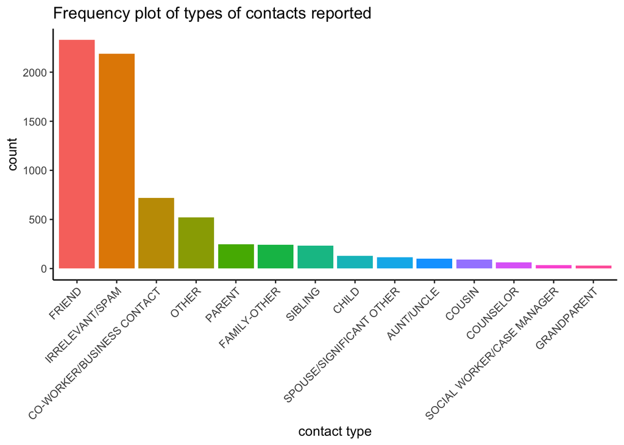

```r
contacts %>%
  mutate(type = fct_infreq(factor(contact_type))) %>%
  ggplot(aes (x = type, fill = type)) +
  geom_bar() +
  xlab("contact type") +
  ggtitle("Frequency plot of types of contacts reported") +
  theme_classic() +
  theme(axis.text.x = element_text(angle = 45, hjust = 1))+
  theme(legend.position="none")
```

#### Phone type

```r
contacts %>%
  mutate(type = fct_infreq(factor(phone_type))) %>%
  tabyl(type, show_na = TRUE) %>%
  adorn_totals("row") %>%
  kable(caption = "Phone type", table.attr = "style='width:60%;'") %>%
  kable_styling(position = "left")
```

Phone type

| type | n | percent |
| --- | --- | --- |
| cell_phone | 4718 | 0.6708375 |
| other_phone1 | 2075 | 0.2950377 |
| home_phone | 231 | 0.0328452 |
| other_phone2 | 9 | 0.0012797 |
| Total | 7033 | 1.0000000 |

#### Context variables

Removing spam for context checks

```r
contacts <- contacts %>%
  filter(spam == "contact")
```

drank past

```r
contacts %>%
  mutate(drank_past = tolower(drank_past),
         drank_past = fct_infreq(factor(drank_past))) %>%
  tabyl(drank_past, show_na = TRUE) %>%
  adorn_totals("row") %>%
  kable(caption = "Drank in past with contact", table.attr = "style='width:60%;'") %>%
  kable_styling(position = "left")
```

Drank in past with contact

| drank_past | n | percent | valid_percent |
| --- | --- | --- | --- |
| never/almost never | 2602 | 0.5371594 | 0.5392746 |
| occasionally | 1568 | 0.3236994 | 0.3249741 |
| almost always/always | 655 | 0.1352188 | 0.1357513 |
| NA | 19 | 0.0039224 | NA |
| Total | 4844 | 1.0000000 | 1.0000000 |

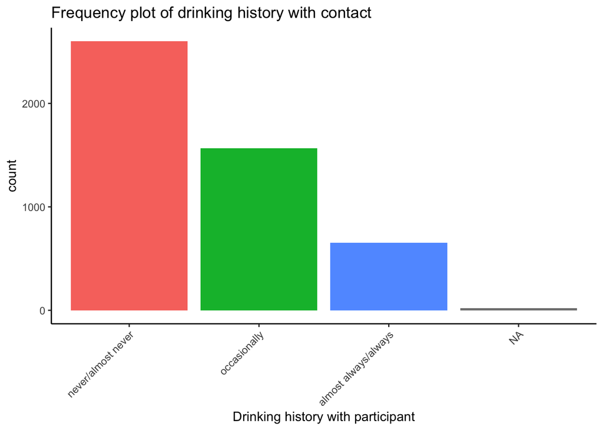

```r
contacts %>%
  mutate(drank_past = tolower(drank_past),
         drank_past = fct_infreq(factor(drank_past))) %>%
  ggplot(aes (x = drank_past, fill = drank_past)) +
  geom_bar() +
  xlab("Drinking history with participant") +
  ggtitle("Frequency plot of drinking history with contact") +
  theme_classic() +
  theme(axis.text.x = element_text(angle = 45, hjust = 1))+
  theme(legend.position="none")
```

Contacts’ Drinking Status

```r
contacts %>%
  mutate(drinker_status = tolower(drinker_status),
         drinker_status = fct_infreq(factor(drinker_status))) %>%
  tabyl(drinker_status, show_na = TRUE) %>%
  adorn_totals("row") %>%
  kable(caption = "Contacts' drinking status", table.attr = "style='width:60%;'") %>%
  kable_styling(position = "left")
```

Contacts’ drinking status

| drinker_status | n | percent | valid_percent |
| --- | --- | --- | --- |
| drinker | 2731 | 0.5637903 | 0.5660104 |
| dont know | 1107 | 0.2285301 | 0.2294301 |
| nondrinker | 987 | 0.2037572 | 0.2045596 |
| NA | 19 | 0.0039224 | NA |
| Total | 4844 | 1.0000000 | 1.0000000 |

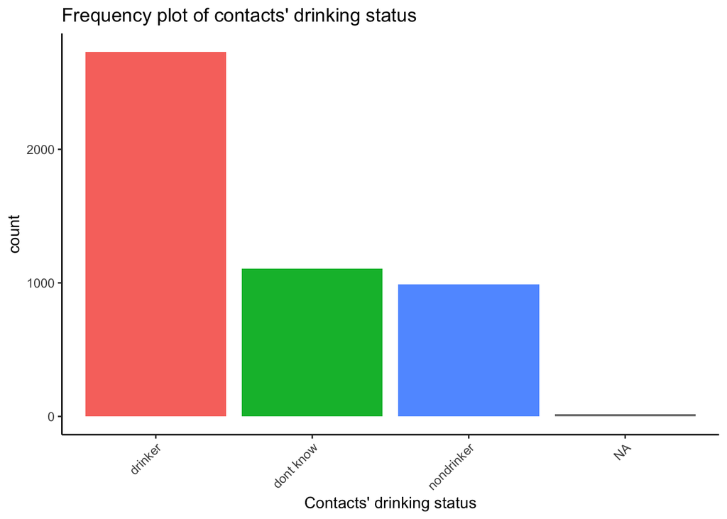

```r
contacts %>%
  mutate(drinker_status = tolower(drinker_status),
         drinker_status = fct_infreq(factor(drinker_status))) %>%
  ggplot(aes (x = drinker_status, fill = drinker_status)) +
  geom_bar() +
  xlab("Contacts' drinking status") +
  ggtitle("Frequency plot of contacts' drinking status") +
  theme_classic() +
  theme(axis.text.x = element_text(angle = 45, hjust = 1))+
  theme(legend.position="none")
```

Does Participant expect that contact would drink in presence of participant

```r
contacts %>%
  mutate(drink_future = tolower(drink_future),
         drink_future = fct_infreq(factor(drink_future))) %>%
  tabyl(drink_future, show_na = TRUE) %>%
  adorn_totals("row") %>%
  kable(caption = "Drink future", table.attr = "style='width:60%;'") %>%
  kable_styling(position = "left")
```

Drink future

| drink_future | n | percent | valid_percent |
| --- | --- | --- | --- |
| yes | 2028 | 0.4186623 | 0.4205724 |
| no | 1857 | 0.3833609 | 0.3851099 |
| uncertain | 937 | 0.1934352 | 0.1943177 |
| NA | 22 | 0.0045417 | NA |
| Total | 4844 | 1.0000000 | 1.0000000 |

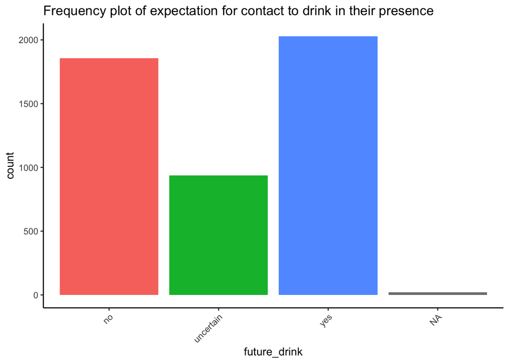

```r
contacts %>%
  mutate(drink_future = tolower(drink_future),
         drinker_status = fct_infreq(factor(drink_future))) %>%
  ggplot(aes (x = drink_future, fill = drink_future)) +
  geom_bar() +
  xlab("future_drink") +
  ggtitle("Frequency plot of expectation for contact to drink in their presence") +
  theme_classic() +
  theme(axis.text.x = element_text(angle = 45, hjust = 1))+
  theme(legend.position="none")
```

Is contact in recovery

```r
contacts %>%
  mutate(recovery = tolower(recovery),
         recovery = fct_infreq(factor(recovery))) %>%
  tabyl(recovery, show_na = TRUE) %>%
  adorn_totals("row") %>%
  kable(caption = "Contacts' recovery status", table.attr = "style='width:60%;'") %>%
  kable_styling(position = "left")
```

Contacts’ recovery status

| recovery | n | percent | valid_percent |
| --- | --- | --- | --- |
| no | 3055 | 0.6306771 | 0.6334232 |
| dont know | 1240 | 0.2559868 | 0.2571014 |
| yes | 528 | 0.1090008 | 0.1094754 |
| NA | 21 | 0.0043353 | NA |
| Total | 4844 | 1.0000000 | 1.0000000 |

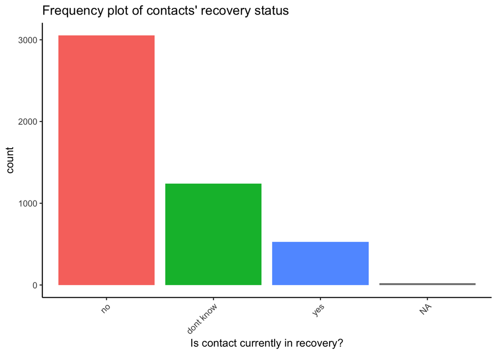

```r
contacts %>%
  mutate(recovery = tolower(recovery),
         recovery = fct_infreq(factor(recovery))) %>%
  ggplot(aes (x = recovery, fill = recovery)) +
  geom_bar() +
  xlab("Is contact currently in recovery?") +
  ggtitle("Frequency plot of contacts' recovery status") +
  theme_classic() +
  theme(axis.text.x = element_text(angle = 45, hjust = 1)) +
  theme(legend.position="none")
```

Contacts’ support of participant’s recovery goals

```r
contacts %>%
  mutate(support = tolower(support),
         support = fct_infreq(factor(support))) %>%
  tabyl(support, show_na = TRUE) %>%
  adorn_totals("row") %>%
  kable(caption = "Contacts' support of participants' recovery goals", table.attr = "style='width:60%;'") %>%
  kable_styling(position = "left")
```

Contacts’ support of participants’ recovery goals

| support | n | percent | valid_percent |
| --- | --- | --- | --- |
| supportive | 2388 | 0.4929810 | 0.4949223 |
| dont know | 2041 | 0.4213460 | 0.4230052 |
| mixed | 166 | 0.0342692 | 0.0344041 |
| neutral | 163 | 0.0336499 | 0.0337824 |
| unsupportive | 66 | 0.0136251 | 0.0136788 |
| no | 1 | 0.0002064 | 0.0002073 |
| NA | 19 | 0.0039224 | NA |
| Total | 4844 | 1.0000000 | 1.0000000 |

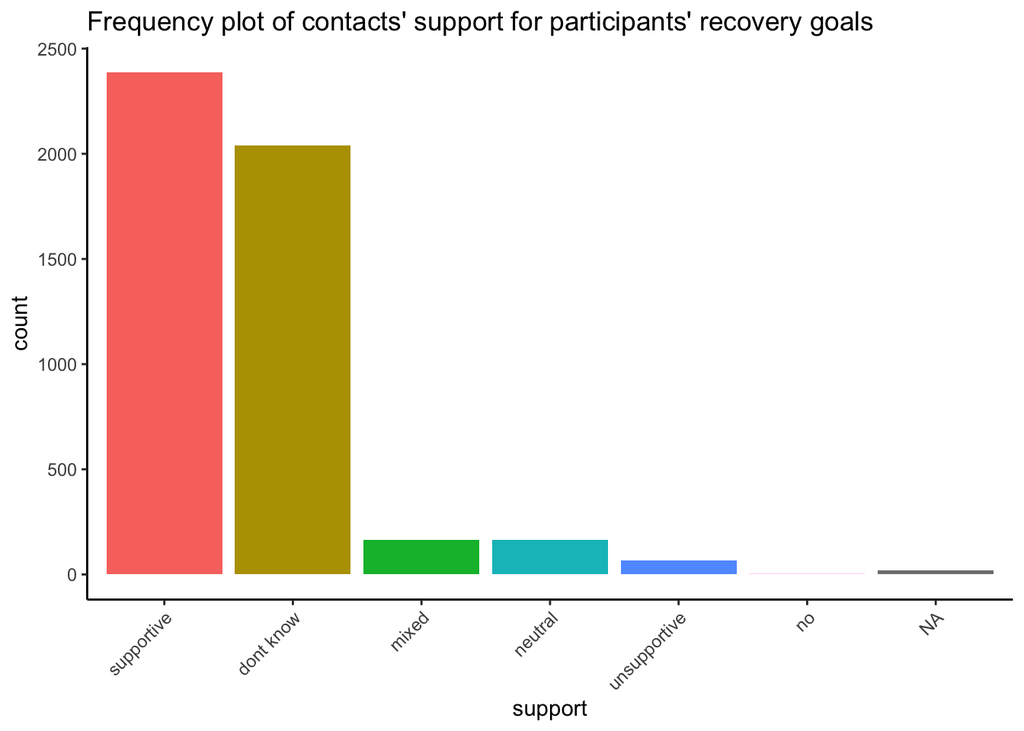

```r
contacts %>%
  mutate(support = tolower(support),
         support = fct_infreq(factor(support))) %>%
  ggplot(aes (x = support, fill = support)) +
  geom_bar() +
  xlab("support") +
  ggtitle("Frequency plot of contacts' support for participants' recovery goals") +
  theme_classic() +
  theme(axis.text.x = element_text(angle = 45, hjust = 1)) +
  theme(legend.position="none")
```

Error: “no” was not a possible response to the item “Do they know about your recovery goals, if so are they supportive”

Participant with “no” response

```r
contacts %>%
  filter(support == "NO") %>%
  kable() %>%
  kable_styling(bootstrap_options = "condensed")
```

| subid | cont_sub | phone_type | number | contact_type | drank_past | drinker_status | drink_future | recovery | support | emotion | spam |
| --- | --- | --- | --- | --- | --- | --- | --- | --- | --- | --- | --- |
| 16 | 1330 | cell_phone | 6033155914 | CO-WORKER/BUSINESS CONTACT | NEVER/ALMOST NEVER | DRINKER | YES | DONT KNOW | NO | PLEASANT | contact |

Emotion associated with typical interactions

```r
contacts %>%
  mutate(emotion = tolower(emotion),
         emotion = fct_infreq(factor(emotion))) %>%
  tabyl(emotion, show_na = TRUE) %>%
  adorn_totals("row") %>%
  kable(caption = "Emotion associated with typical interactions", table.attr = "style='width:60%;'") %>%
  kable_styling(position = "left")
```

Emotion associated with typical interactions

| emotion | n | percent | valid_percent |
| --- | --- | --- | --- |
| pleasant | 3633 | 0.7500000 | 0.7527973 |
| mixed | 862 | 0.1779521 | 0.1786158 |
| neutral | 233 | 0.0481007 | 0.0482801 |
| unpleasant | 98 | 0.0202312 | 0.0203067 |
| NA | 18 | 0.0037159 | NA |
| Total | 4844 | 1.0000000 | 1.0000000 |

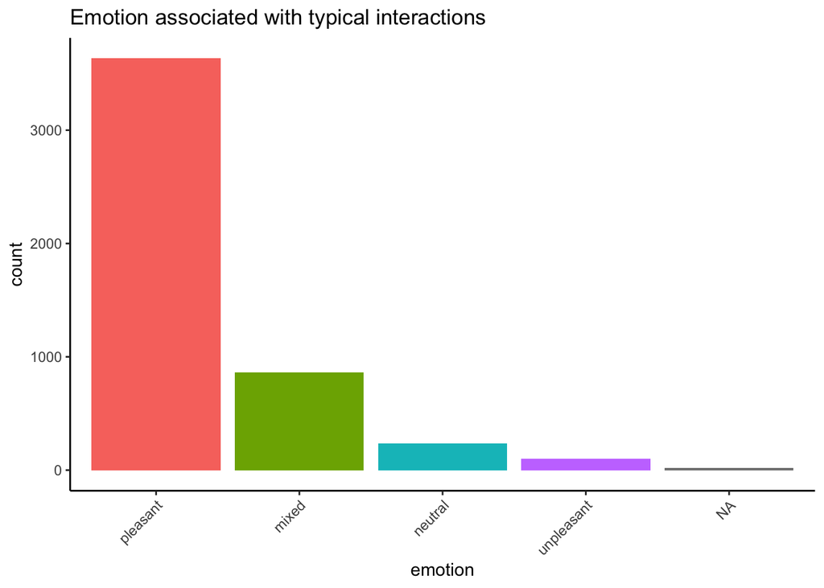

```r
contacts %>%
  mutate(emotion = tolower(emotion),
         emotion = fct_infreq(factor(emotion))) %>%
  ggplot(aes (x = emotion, fill = emotion)) +
  geom_bar() +
  xlab("emotion") +
  ggtitle("Emotion associated with typical interactions") +
  theme_classic() +
  theme(axis.text.x = element_text(angle = 45, hjust = 1)) +
  theme(legend.position="none")
```